# Projekt - Analiza spektralna w ekonomii i finansach

Faustyna Bąk

26-01-2023

## **Definicja problemu**

Głównym problemem w tym projekcie będzie szukanie cykli i dominujących częstotliwości na danych dotyczących średniej temperatury na Malcie w latach 1901-2021, a także prezentowanie tych danych.

## **Opis danych**

Dane pochodzą z [Download Data | Climate Change Knowledge Portal (worldbank.org)](https://climateknowledgeportal.worldbank.org/download-data). Przedstawiają średnią roczną temperaturę na Malcie w stopniach Celsjusza. Malta znajduje się w strefie klimatu subtropikalnego typu śródziemnomorskiego, z bardzo łagodnymi zimami i długimi ciepłymi, częściowo gorącymi latami. Średnia roczna temperatura wynosi 23 °C w dzień i 16 °C w nocy.

```r
#pakiety
library(outliers)
library(lattice)
library(oce)
library(multitaper)
require(multitaper)
library(kableExtra)
library(knitr)
```

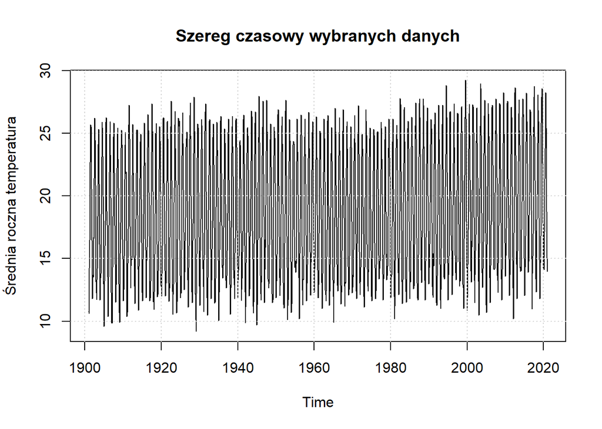

```r
#wczytanie danych
data<-read.csv("Malta.csv", sep=",", dec=".",header=T)

kol2<-data[,2]

data2<-ts((kol2),start=1901,end = 2021,frequency=12)
plot(data2, type="l", ylab="Średnia roczna temperatura",xlab="Time",col=grey(.05),main="Szereg czasowy wybranych danych")
grid()
```

Z ze wględu na dużą liczbę danych wykres szerugu czasowego nie jest zbyt przejrzysty. Można jednak wywnioskować, że temperatura zmienia się cyklicznie. W ciągu 100 lat średni poziom temperatury zdecydowanie się zwiększył.

## **Preprocessing**

### Test Cochrana

Z racji bardzo dużej ilości danych wykonany zostanie test Cochrana, aby sprawdzić występują odchylające się wariancje w grupach. Dane zostaną podzielone na 121 grup, ponieważ zakres badanych danych obejmuje 121 lat.

```r
library(outliers)

vec <- data$Value
d=data.frame(x=vec, group=rep(1:121, length(vec)))
cochran.test(x~group,d)
```

```
##
##  Cochran test for outlying variance
##
## data:  x ~ group
## C = 0.011421, df = 1452, k = 121, p-value < 2.2e-16
## alternative hypothesis: Group 95 has outlying variance
## sample estimates:
##        1        2        3        4        5        6        7        8
## 31.09451 26.24091 32.90088 24.43921 23.69580 23.46402 29.12707 33.11321
##        9       10       11       12       13       14       15       16
## 36.82076 29.40347 31.97670 24.16786 24.59596 21.83348 25.74844 27.18322
##       17       18       19       20       21       22       23       24
## 27.86076 32.46117 26.17729 31.72210 35.80215 34.37973 33.58056 29.36295
##       25       26       27       28       29       30       31       32
## 27.06127 25.06378 21.12356 22.15584 23.68791 21.77052 25.07012 27.73390
##       33       34       35       36       37       38       39       40
## 30.50715 33.65599 35.37636 29.75942 23.71247 18.73722 22.53645 28.91771
##       41       42       43       44       45       46       47       48
## 23.71531 22.42817 28.92651 28.75207 30.94080 34.17019 30.34923 25.47225
##       49       50       51       52       53       54       55       56
## 30.52681 28.63944 23.44744 24.58289 22.19216 23.34580 25.95819 24.46123
##       57       58       59       60       61       62       63       64
## 32.18612 27.43584 25.55372 24.60171 21.39686 25.38715 19.75860 24.24776
##       65       66       67       68       69       70       71       72
## 22.97163 23.86631 29.19772 31.52212 32.00640 27.62371 24.77569 29.76984
##       73       74       75       76       77       78       79       80
## 29.94118 27.50910 28.20577 25.15105 22.69397 26.40292 27.42679 29.21838
##       81       82       83       84       85       86       87       88
## 29.60645 31.61359 36.09621 28.06073 27.16394 25.79089 24.52087 25.89581
##       89       90       91       92       93       94       95       96
## 25.15070 24.68494 23.53015 29.60937 32.52039 31.29049 37.55815 34.33012
##       97       98       99      100      101      102      103      104
## 27.16224 22.44605 20.30371 23.77175 22.51571 21.89426 20.55374 25.02420
##      105      106      107      108      109      110      111      112
## 30.51753 29.90610 26.47833 23.94200 24.80631 24.37601 21.97444 23.68081
##      113      114      115      116      117      118      119      120
## 25.41579 24.41550 26.29535 28.71949 34.69014 30.90941 26.68125 25.39508
##      121
## 28.41479
```

W teście Cochrana p-value wynosi 0, czyli na poziomie istotności 5% istnieją podstawy do odrzucenia hipotezy zerowej na rzecz hipotezy alternatywnej mówiącej o tym, że wariancja w 95 grupie znacząco odstaje od pozostałych grup. Wynika to ze specyfiki danych, w rocznym cyklu zdarzają się miesiące z niższą bądź wyższą temperaturą.

### Brakujące wartości

#### Statystyki opisowe

```r
summary(data2)
```

```
##    Min. 1st Qu.  Median    Mean 3rd Qu.    Max.
##    9.19   14.09   18.15   18.76   23.82   29.25
```

Ze statystyk wynika, że średnio w każdym miesiącu na Malcie jest 18 stopni Celsujsza. Najwyższa średnia miesięczna temperatura osięgnęła wartość ponad 29 stopni Celsjusza. Z summary wynika, że w danych nie występują braki w danych, czyli dane są kompletne.

## **Dekompozycja szeregu czasowego i usuwanie trendu z danych**

### Metoda LOESS

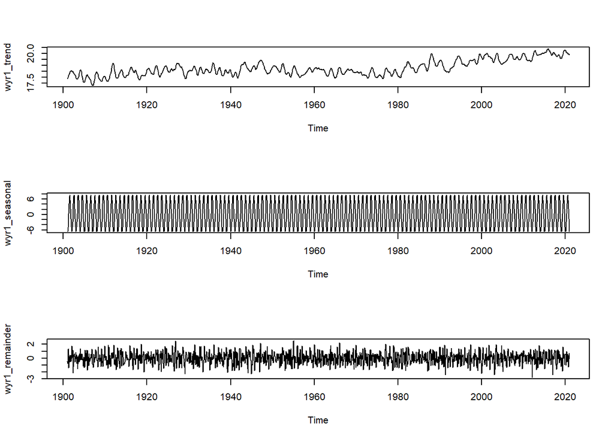

```r
par(mfrow=c(3,1))

#Wygładzanie metodą LOESS
wyr1 <- stl(data2,"per") #funkcja do LOESS
sz = wyr1$time.series
wyr1_seasonal=sz[,1]
wyr1_trend=sz[,2]
wyr1_remainder=sz[,3]

#Wygładzanie średnimi ruchomymi
plot(wyr1_trend)
plot(wyr1_seasonal)
plot(wyr1_remainder)
```

### Średnie ruchome

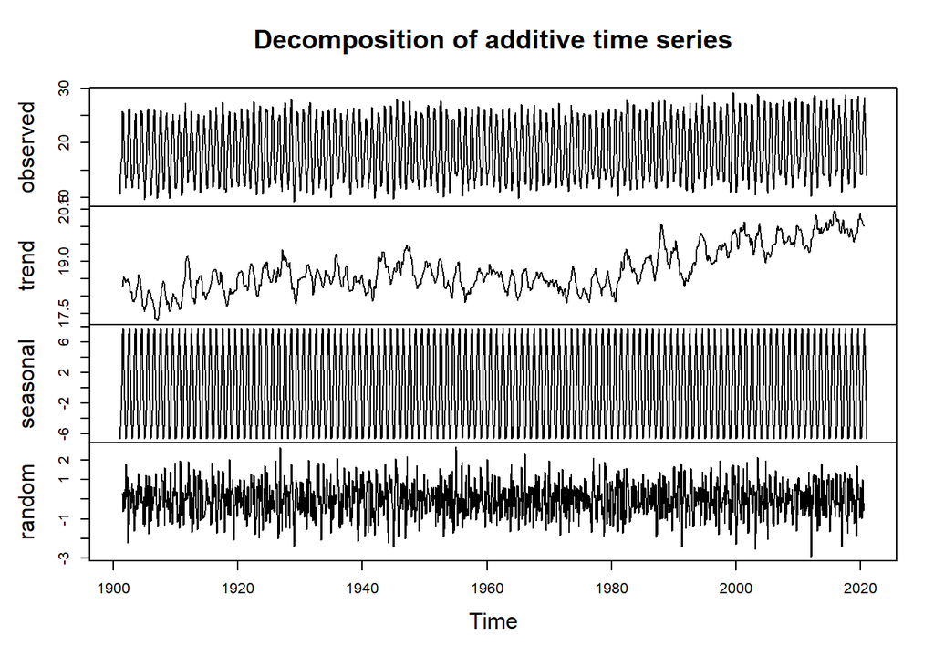

```r
data_dekom<-decompose(data2)
plot(data_dekom)
```

### Usuwanie trendu z danych

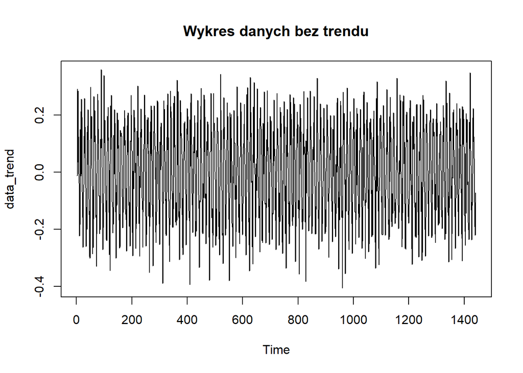

```r
#Wykres danych bez trendu
data_trend<-diff(ts(log(data2)))
plot(data_trend, main="Wykres danych bez trendu")
```

### Wygładzanie średnią ruchomą i określenie rzędu okresowości

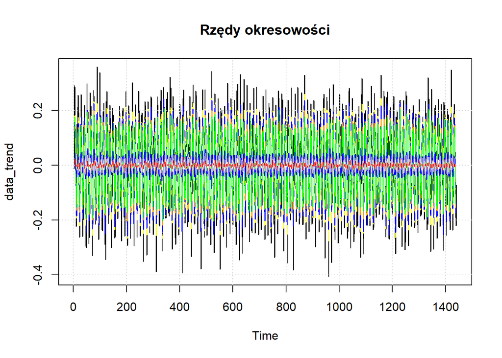

```r
#WYGLADZANIE SREDNIA RUCHOMA:
plot(data_trend,type="l", main="Rzędy okresowości")
grid()
#wygladzenie srednia ruchoma rzedu 2
f2d<-c(1/4,0.5,1/4)
d2d <-filter(data_trend,f2d,sides=2)
lines(d2d, col="yellow")
#wygladzenie srednia ruchoma rzedu 3
f3d<-c(1/3,1/3,1/3)
d3d<-filter(data_trend,f3d,sides=2)
lines(d3d, col="blue")
#wygladzenie srednia ruchoma rzedu 4
f4d<-c(1/8,1/4,1/4,1/4,1/8)
d4d <-filter(data_trend,f4d,sides=2)
lines(d4d, col="orange")
#wygladzenie srednia ruchoma rzedu 5
f5d<-c(1/5,1/5,1/5,1/5,1/5)
d5d <-filter(data_trend,f5d,sides=2)
lines(d5d, col="green")
#wygladzanie srednia ruchoma rzedu 10
f10d<-rep(1/10,10)
d10d<-filter(data_trend,f10d,sides=2)
lines(d10d,col="blue")
#wygladzanie srednia ruchoma rzedu 12
f12d<-rep(1/12,12)
d12d<-filter(data_trend,f12d,sides=2)
lines(d12d,col="red")
#wygladzanie srednia ruchoma rzedu 20
f20d<-rep(1,20)/20
d20d <- filter(data_trend,f20d,sides=2)
lines(d20d, col="grey")
```

Z wykresu najbardziej odznacza się kolor czerwony - najbardziej wygładza wykres, czyli najlepsze wygładzenia średnią ruchomą uzyskiwane jest dla średniej ruchomej rzędu 12.

### Najbardziej wygładzony wykres

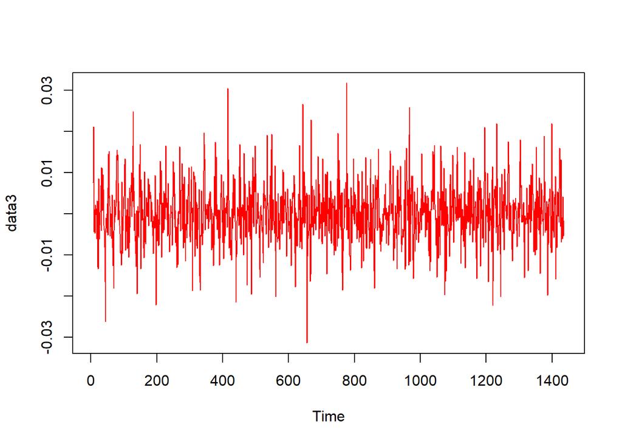

```r
data3<-d12d
plot(data3,type="l",col="red")
```

## **Periodogramy**

### Periodogram naiwny dla danych bez trendu

```r
P2data<- spec.pgram(data_trend,log='no', taper=0,pad=0, fast=FALSE,demean=FALSE,detrend=TRUE)
```

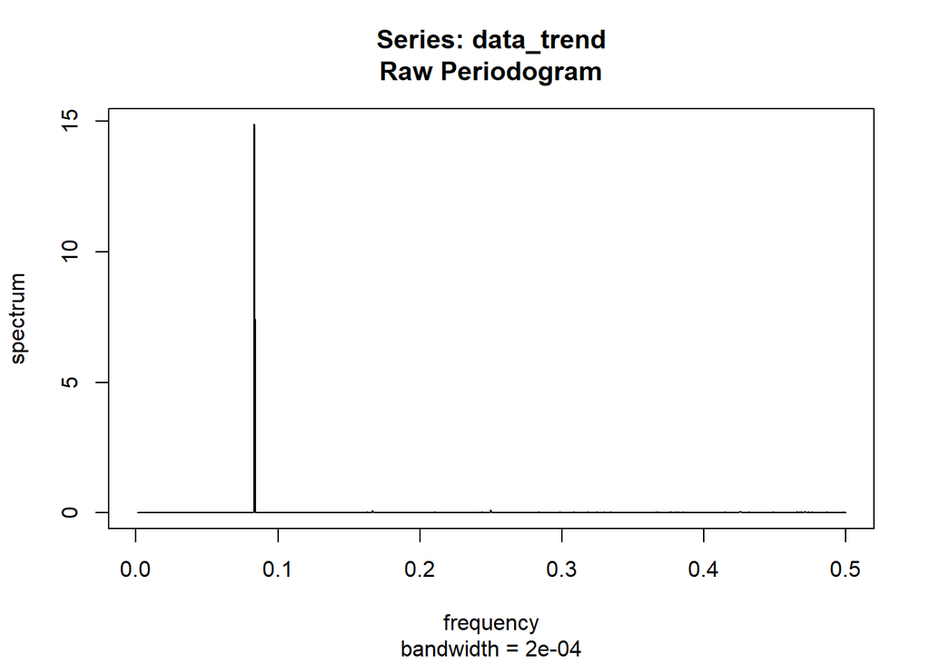

Na wykresie periodogramu naiwnego dla danych bez trendu widoczne sa piki dla częstotliwości około 0.084 oraz bardzo słabo widoczne piki dla częstotliwości 0.17 i 0.25. Według najwyższego piku cykl główny powtarza sie wiec co 1/0.084 = 11.9 miesiaca, czyli wytępuje cykl roczny. Natomiast nieznaczące cykle występują co 1/0.17 = 5,9 miesięcy (półroku) lub 1/0.25 = 4 miesięcy - co może być związane z porami roku.

### Periodogram naiwny

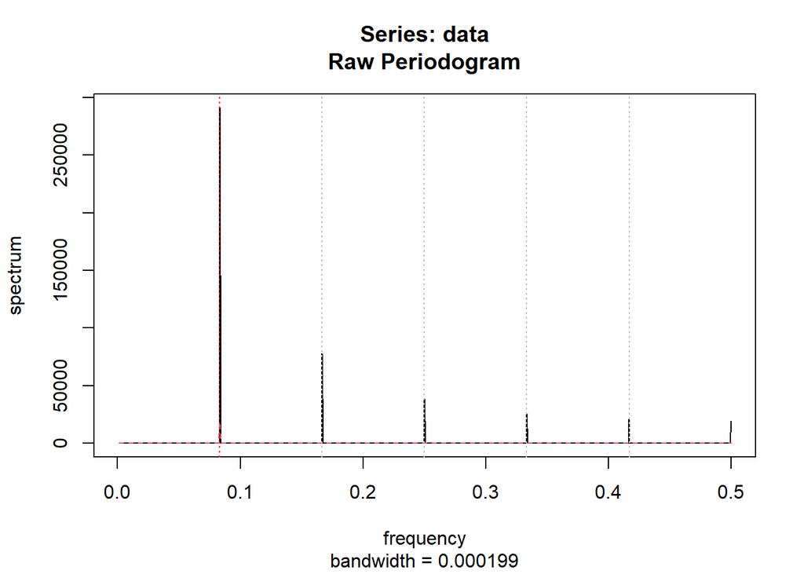

```r
#PERIODOGRAM NAIWNY:
Pd<- spec.pgram(data,log='no', taper=0,pad=0, fast=FALSE,demean=FALSE,detrend=TRUE)
abline(v=1/12,lty='dotted',col="red")
abline(v=0.1667,lty='dotted',col="grey")
abline(v=0.25,lty='dotted',col="grey")
abline(v=0.3335,lty='dotted',col="grey")
abline(v=0.417,lty='dotted',col="grey")
```

### Periodogram wygładzony oknem Daniella

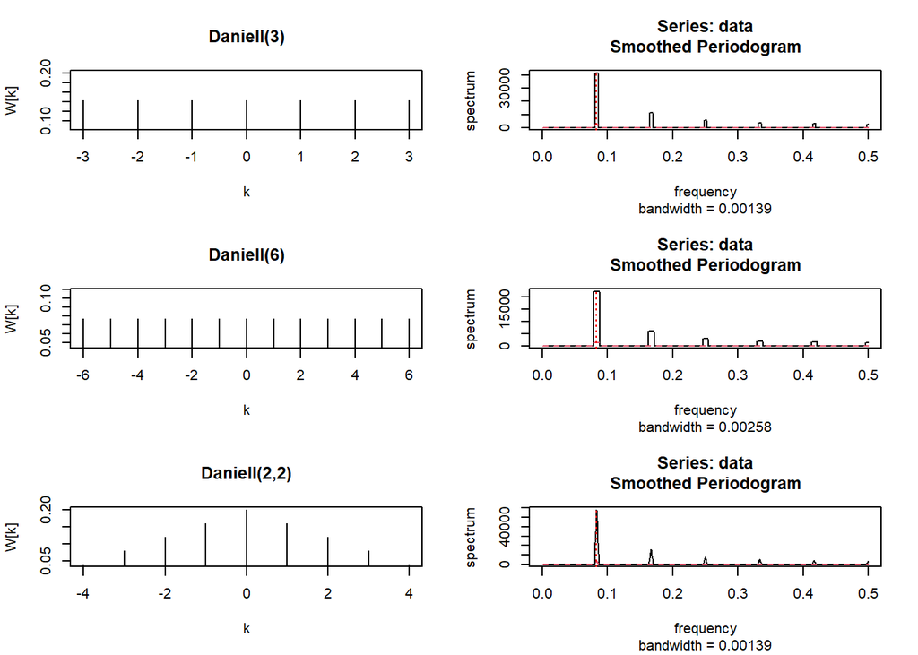

```r
#PERIODOGRAM WYGLADZONY OKNEM DANIELLA:
par(mfrow=c(3,2))
window_1d<-kernel('daniell',3)
window_2d<-kernel('daniell',6)
window_3d<-kernel('daniell',c(2,2))
plot(window_1d)
P1<-spec.pgram(data,kernel=window_1d,log='no',taper=0,fast=F,detrend=T)
abline(v=1/12,lty='dotted',col="red")
plot(window_2d)
spec.pgram(data,kernel=window_2d,log='no',taper=0,fast=F,detrend=T)
abline(v=1/12,lty='dotted',col="red")
plot(window_3d)
spec.pgram(data,kernel=window_3d,log='no',taper=0,fast=F,detrend=T)
abline(v=1/12,lty='dotted',col="red")
```

Periodogramy są bardzo podobne. Periodogram wygladzony oknem Daniella m=c(2,2) potwierdza to, co wykazał periodogram naiwny i periodogram naiwny dla danych bez trendu - częstotliwość 1 roku. Periodogramy wygladzone oknami Daniella m=3 oraz m=6 także oscylują wokoł cyklu rocznego.

### Odfiltrowanie dominującego sygnału i ponowne wyznaczenie periodogramu

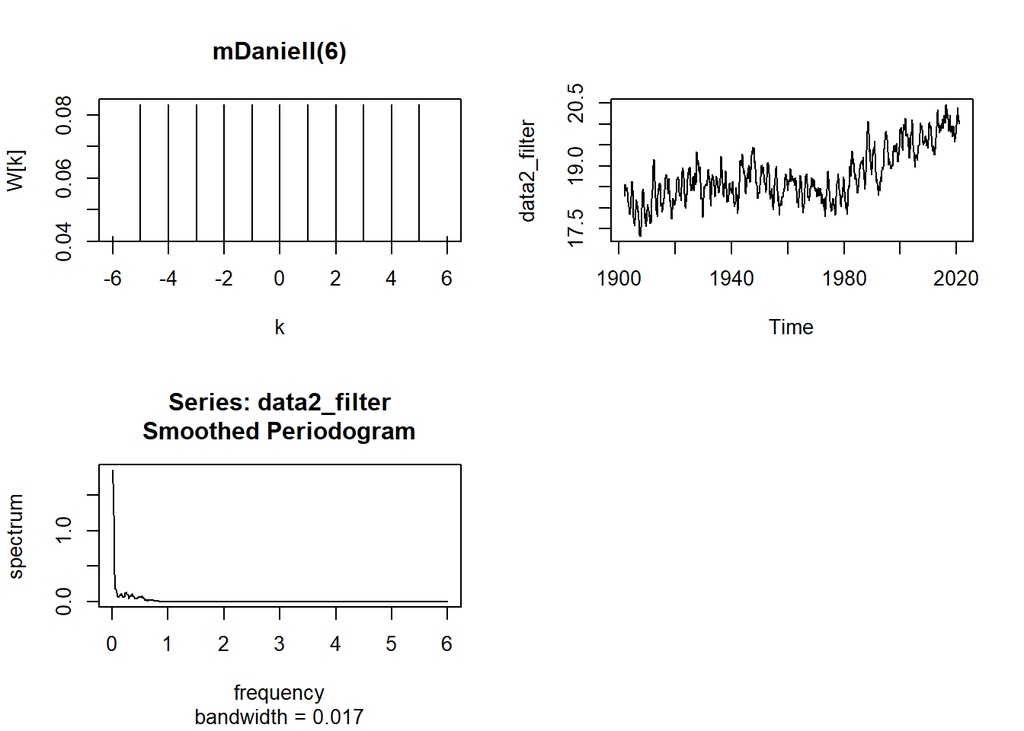

```r
#ODFILTROWANIE DOMINUJACEGO SYGNALU I PONOWNE WYZNACZENIE PERIODOGRAMU:
par(mfrow=c(2,2))
k=kernel("modified.daniell",6)
plot(k)
data2_filter<-kernapply(data2,k)
#Po odfiltrowaniu:
plot.ts(data2_filter)
#Periodogram po odfiltrowaniu:
spec.pgram(data2_filter,kernel('daniell',3),log='no',taper=0,fast=F)
```

Po odfiltrowaniu dominujacej częstotliwości rocznej i ponownym wyznaczeniu periodogramu, okazuje się, że poza przedziałem <0,1> nie występują juz żadne inne piki, więc nie wystepuje żadna inna istotna częstotliwość.

### Periodogram Welcha

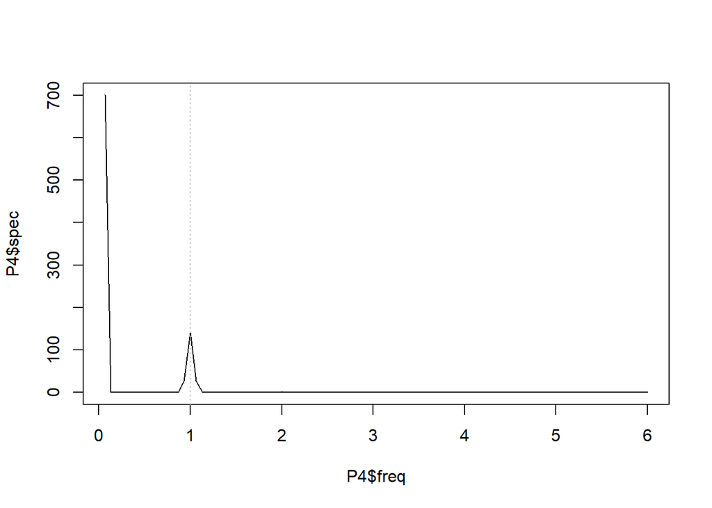

```r
library(oce)
require(oce)
#PERIODOGRAM WELCHA
datats<-ts(data,frequency=12)
datats<-datats-mean(datats)
#wykres oeriodogramu welcha wraz z periodogramem naiwnym
P4<-pwelch(data2,noverlap=10,plot=FALSE)
plot(P4$freq,P4$spec,type="l")
abline(v=1,lty='dotted',col="grey")
```

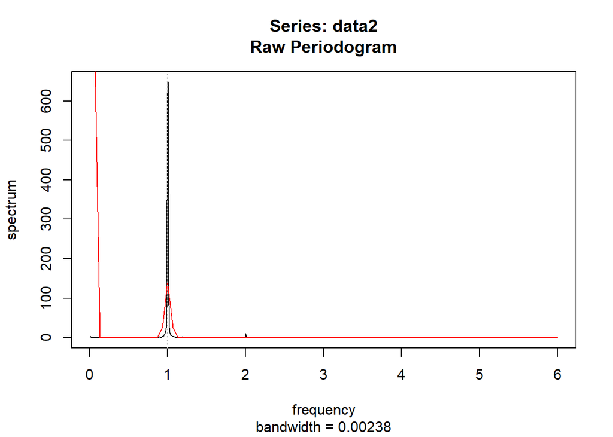

```r
#write.csv(cbind(P4$spec,P4$freq),"sd4.csv")

spec.pgram(data2,log='no',taper=0,fast=T)
lines(P4$freq,P4$spec,type="l", col="red")
abline(v=1,lty='dotted',col="grey")
```

### Periodogram Lomb-Scargle

```r
library(lomb)

LS<-lsp(data[,2],times=data[,1],type='period',ofac=5,alpha=0.05)
```

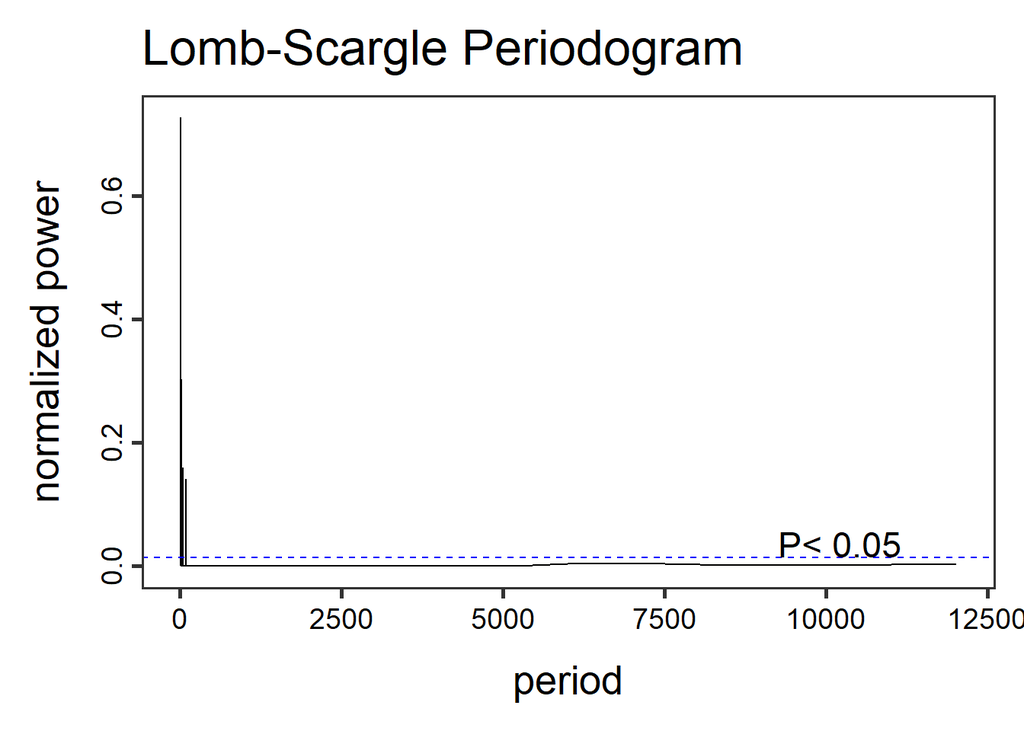

### Periodogram MTM

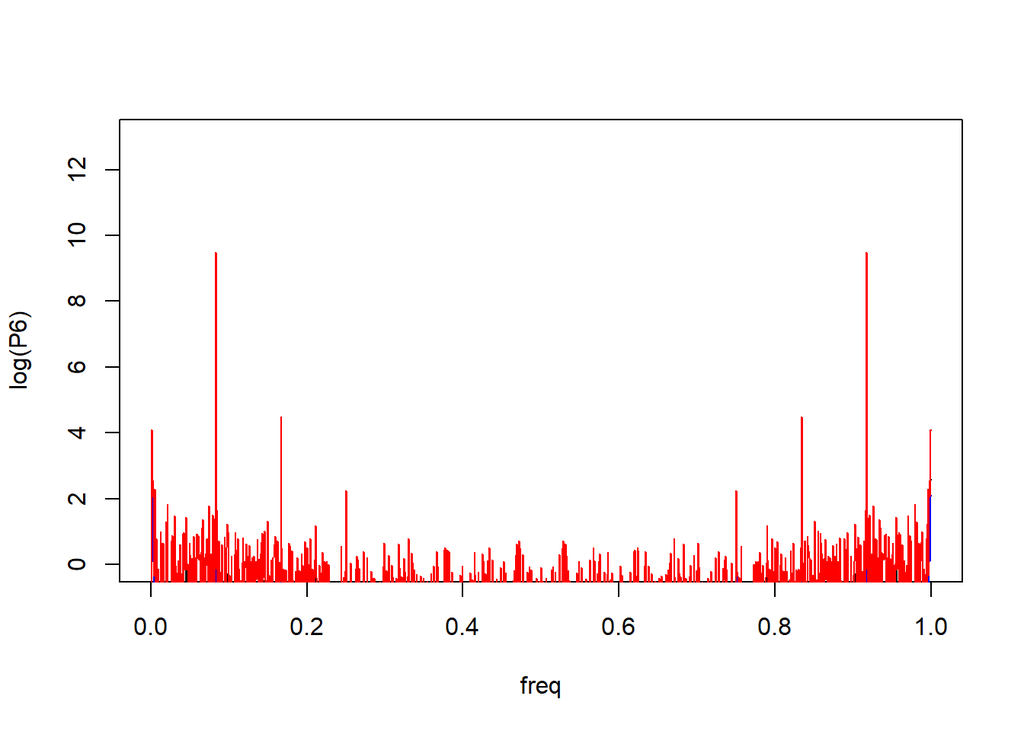

```r
#PERIODOGRAM MTM
require(multitaper)
data5<-as.ts(kol2)
freq<-seq(from=0,to=1, length=length(data5))
uu<-as.ts(data5)
uu<-uu-mean(uu)
P6<-abs(fft(uu))^2/(2*pi*length(uu))
L<-qchisq(.2,2)
U<-qchisq(.8,2)
#wyznaczenie przedzialow ufnosci
plot(freq,log(P6),type="l",ylim=c(0,13))
D<-as.matrix(2*P6/L)
G<-as.matrix(2*P6/U)
lines(freq,log(G),type="l",col="blue")
lines(freq,log(D),type="l",col="red")
```

```r
#par(mfrow=c(1,1))
#linie istotnosci dla statystyki F
Spec2<-spec.mtm(data5,Ftest=TRUE)
```

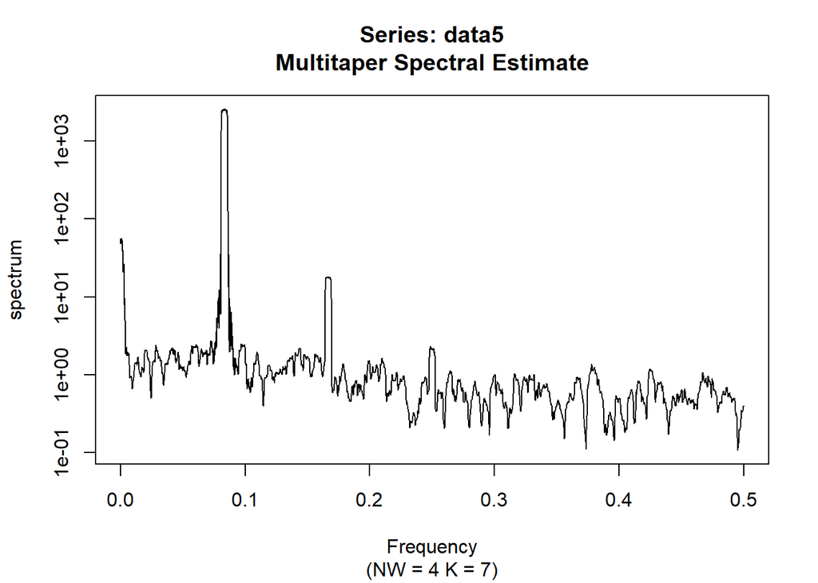

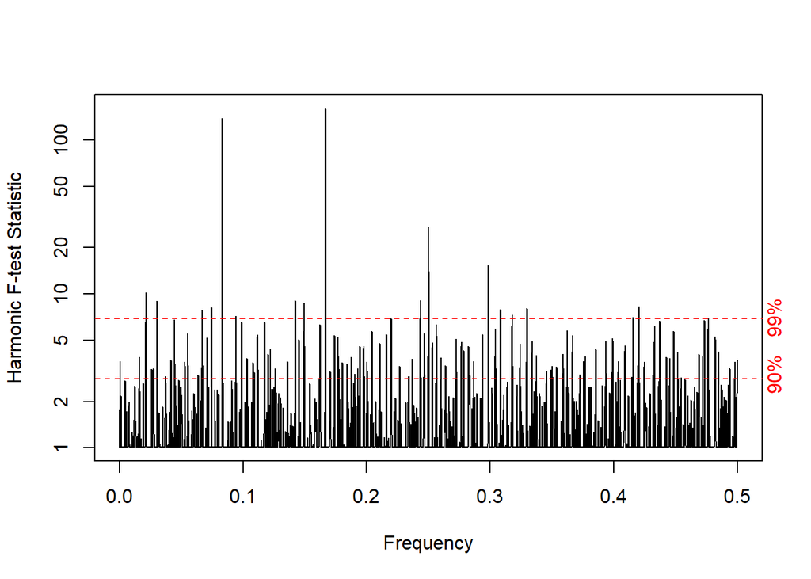

```r
plot(Spec2,Ftest=TRUE,siglines=c(0.90,0.99))
```

```r
#write.csv(cbind(Spec2$mtm$Ftest,Spec2$freq),"sd2.csv")
```

**Na poziomie istotnosci alfa = 0.1 dominuje bardzo wiele częstoliwości, trudno jednoznacznie wskazać kilka najważniejszych.**

```r
#Przedzial ufnosci
Spec2<-spec.mtm(data5,Ftest=TRUE,jackknife=TRUE)
```

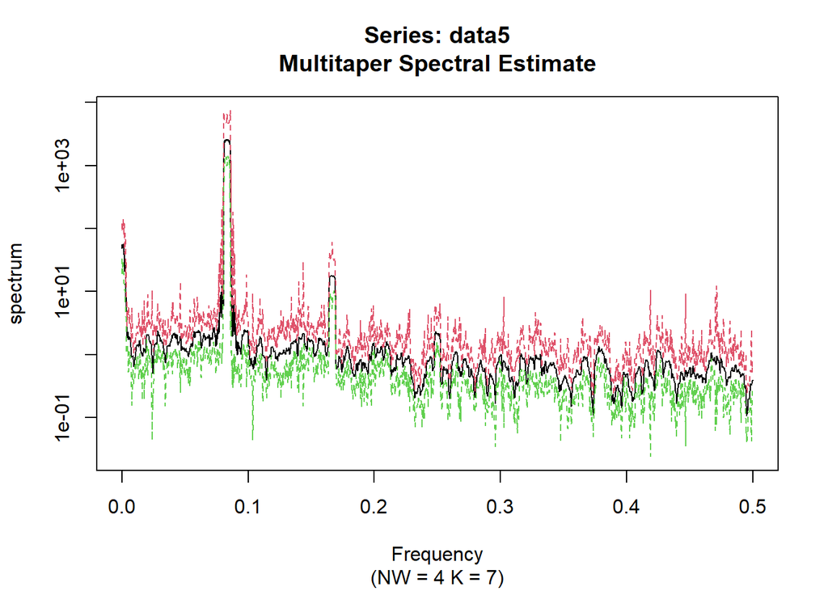